# COMBINE X SUDATA X SPDSC X GraftAI Hackathon

Alex Qin

August 16, 2024

Welcome to the bioinformatics stream of the hackathon! In this introductory pipeline, we’ll cover:

- Introduction to bulk transcriptomics data
- A beginners guide to analyzing bulk transcriptomics
- Visualizing results

This workflow will be directly obtaining and using the data from the [PROMAD](https://shiny.maths.usyd.edu.au/PROMAD/) database, containing transplant transcriptomic data from a set of different studies. These studies can usually be traced back to their original paper by typing in their GSE accession ID (e.g. `GSE46474`) into google. This can be an avenue for analysis of more in-depth questions.

All data downloaded from PROMAD will be neatly stored as dataframes in a `.Rds` format, allowing you to easily read it into R using the `readRDS()` function. When downloading multiple datasets, each of these will be stored as a dataframe in a list of dataframes.

# 1 Getting started

## 1.1 Collecting Data

The first step in analyzing bulk transcriptomics data is to collect the data. The `limma` package will be used for the analysis of transcriptomic data. Here, we use the `readRDS()` function to read in the file. The file will be stored as a list consisting of 1 dataframe, as we’ve only specified 1 dataset from the PROMAD database.

```r
# Load in the libraries
library(limma)
library(dplyr)
library(ggplot2)

# Loading in data
gse <- readRDS("microarray.Rds")

# Loading in the first (and only) dataframe of our list
gse <- gse[[1]]
```

## 1.2 Objects in R

After loading the dataset in as a dataframe, we can inspect it.

```r
# Take a look at the data
dplyr::glimpse(gse)
```

```
## Rows: 23,521
## Columns: 42
## $ X           <chr> "DDR1 /// MIR4640", "RFC2", "HSPA6", "PAX8", "GUCA1A", "MI…
## $ AR          <dbl> 5.722406, 4.755610, 8.216229, 7.915615, 2.768341, 6.994332…
## $ Control     <dbl> 6.419162, 4.843733, 6.707188, 7.191130, 2.670747, 6.350628…
## $ AR.1        <dbl> 6.219222, 4.641672, 7.738964, 7.783882, 2.489202, 6.774133…
## $ Control.1   <dbl> 6.266114, 4.504503, 7.586340, 7.328809, 2.406849, 6.709585…
## $ AR.2        <dbl> 6.043627, 5.102913, 8.432012, 6.909685, 2.471741, 6.913674…
## $ Control.2   <dbl> 5.637844, 4.682618, 7.877483, 7.122386, 2.436244, 6.511939…
## $ AR.3        <dbl> 5.871970, 4.800047, 8.243170, 7.165799, 2.543517, 6.991003…
## $ Control.3   <dbl> 6.178636, 5.297240, 8.013875, 6.339073, 2.691704, 6.721574…
## $ AR.4        <dbl> 5.978075, 4.934306, 7.892272, 7.139232, 2.517809, 6.607432…
## $ Control.4   <dbl> 5.814596, 4.815109, 8.007329, 7.477882, 2.704222, 6.450777…
## $ AR.5        <dbl> 5.413572, 4.859533, 8.298351, 6.386217, 2.432394, 6.672643…
## $ Control.5   <dbl> 6.026822, 5.238449, 7.578647, 7.237436, 2.456118, 6.386052…
```

[output cut: 29 more lines]

# 2 Microarray

To be entirely accurate, the dataset that we just loaded in, `GSE46474`, is not strictly a RNA sequencing dataset. It is a microarray dataset. Microarray technology was the first high-throughput technology used to measure gene expression. Microarray data is a bit different from RNAseq data, in that it is a array based technology, where the expression of a gene is measured by the intensity of a spot on a microarray chip. This is in contrast to RNAseq, where the expression of a gene is measured by the number of reads that map to that gene.

As such the analysis of microarray data is a bit different from RNAseq data. In this section, we will cover how to analyse microarray data.

## 2.1 Introduction

You will notice in our dataframe that we have 2 columns that look likes genes. Column `X` and `Gene_Symbol`. You will notice that `X` sometimes has 2 gene names. This is because some probe IDs map to multiple genes because the probe is designed to bind to a region of the gene that is common to multiple genes. This is a common issue with microarray data. `Gene_Symbol` has simply taken the first element.

```r
head(gse$X)
```

```
## [1] "DDR1 /// MIR4640" "RFC2"             "HSPA6"            "PAX8"
## [5] "GUCA1A"           "MIR5193 /// UBA7"
```

```r
head(gse$Gene_Symbol)
```

```
## [1] "DDR1"    "RFC2"    "HSPA6"   "PAX8"    "GUCA1A"  "MIR5193"
```

Next, we’ll want to remove the `X` column and set `Gene_Symbol` as our rownames. However, often times we’ll get duplicated or missing gene names in our dataset. This can happen for a range of reasons, and you can decide to examine these further, but for the sake of brevity, we’ll be simply filtering these genes out.

```r
gse$X <- NULL

idx = which(!is.na(gse$Gene_Symbol) & !duplicated(gse$Gene_Symbol))
gse = gse[idx, ]

# Now we can set the gene symbols as the rownames
rownames(gse) = gse$Gene_Symbol

gse$Gene_Symbol <- NULL
```

## 2.2 Normalization & PCA

Normalization is the process of removing technical variation from the data. We can first assess whether the data needs to be normalized by looking at the distribution of the data. We can do this by plotting a boxplot of the data.

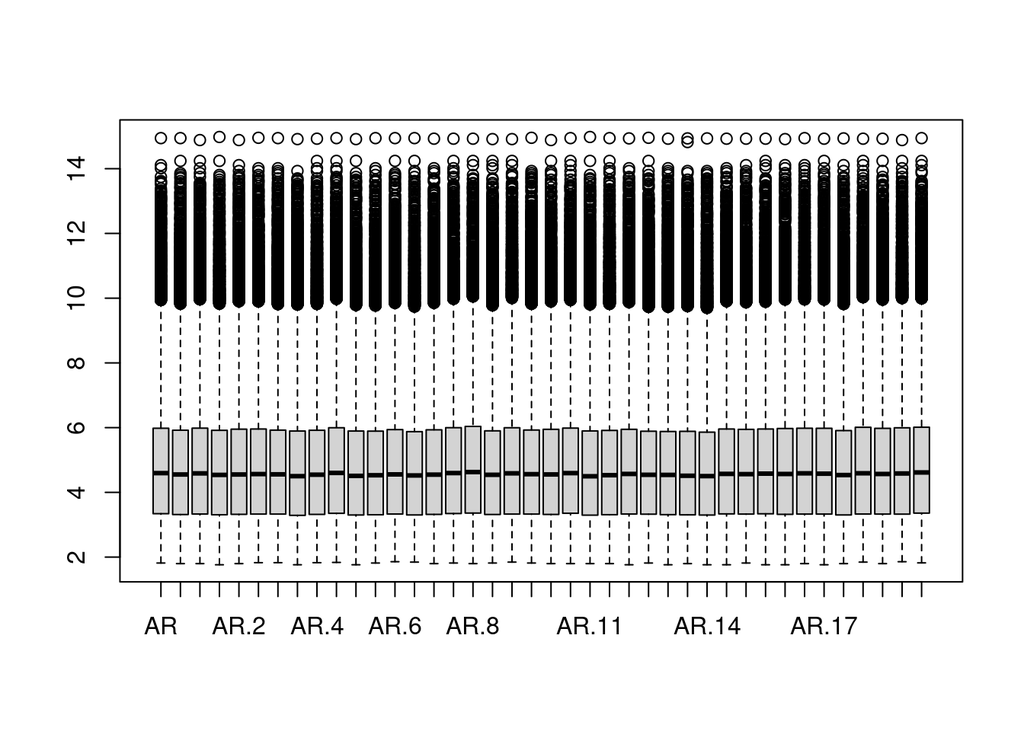

```r
boxplot(gse)
```

As we can see the data is already normalized and so we don’t need to normalize it once again. All data in PROMAD is already normalized.

Now that we have normalized the data, we can perform a principal componenet analysis (PCA) to visualize the data. PCA is a dimensionality reduction technique that reduces the dimensionality of the data while preserving the variance of the data. We can use the `prcomp` function to perform PCA.

```r
pca = prcomp(t(gse), scale=TRUE, centre = TRUE)
```

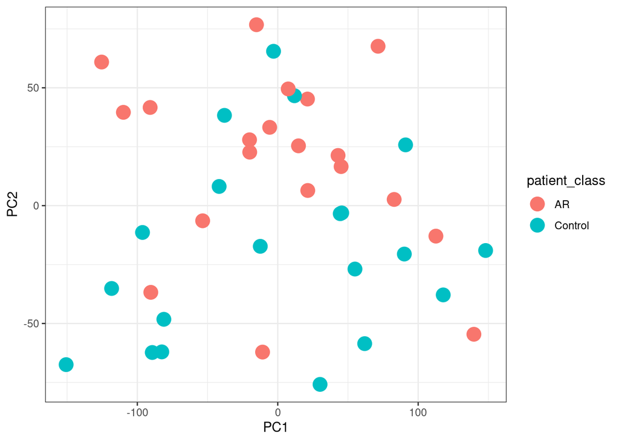

```r
rejection = grepl("AR", colnames(gse)) # grepl is a function that searches for a pattern in a string
patient_class = ifelse(rejection, "AR", "Control") # ifelse is a function that assigns a value based on a condition
pca$x %>%
  as.data.frame() %>%
  mutate(patient_class) %>%
  ggplot(aes(x = PC1, y = PC2, color = patient_class)) + geom_point(size = 5) + theme_bw()
```

## 2.3 Differential Expression Analysis

In order to identify genes that are differentially expressed between two groups, we can use the `limma` package. The `limma` package uses a linear model to identify differentially expressed genes. The `limma` package takes in a `ExpressionSet` object and a design matrix as input.

To create the design matrix we can use the `model.matrix` function. The design matrix is a matrix that describes the experimental design of the study. Each column of the design matrix corresponds to a group in the study. The `model.matrix` function takes in a formula and a data frame as input. The formula describes the experimental design of the study. The data frame contains the sample information.

First, we’ll need to obtain the class labels from the column names.

```r
# Clean up the class labels
rejection = grepl("AR", colnames(gse)) # grepl is a function that searches for a pattern in a string
patient_class = ifelse(rejection, "AR", "Control") # ifelse is a function that assigns a value based on a condition

table(patient_class)
```

```
## patient_class
##      AR Control
##      20      20
```

Now that we have the class labels, we can create the design matrix.

```r
# Create the design matrix
design = model.matrix(~0 + patient_class)
colnames(design) = c("AR", "Control")

# Fit the linear model
fit = lmFit(gse, design) # lmFit is a function that fits a linear model to the data
contrast = makeContrasts(Rejection = AR - Control, levels=design) # makeContrasts is a function that creates a contrast matrix to specify the comparison we want to make in our analysis.
fit2 = contrasts.fit(fit, contrast) # contrasts.fit is a function that fits the contrast matrix to the linear model
efit = eBayes(fit2, robust=TRUE) # eBayes is a function that estimates the variance of the data given we have a lot of features.
```

Finally, we can extract the differentially expressed genes using the `topTable` function. This function takes in the `eBayes` object and a threshold as input.

```r
topTable = topTable(efit, coef="Rejection", number=Inf)

library(DT)
topTable %>%
  round(3) %>%
  top_n(10, abs(t)) %>%
  datatable()
```

|  | logFC | AveExpr | t | P.Value | adj.P.Val | B |
| --- | --- | --- | --- | --- | --- | --- |
| LOC101060275 | 0.748 | 7.185 | 6.751 | 0 | 0.001 | 8.203 |
| GRAMD1A | 0.688 | 6.861 | 6.531 | 0 | 0.001 | 7.58 |
| ALDH3A2 | -0.903 | 7.447 | -5.659 | 0 | 0.007 | 5.081 |
| RBP4 | 0.543 | 4.303 | 5.648 | 0 | 0.007 | 5.055 |
| FAM78B | -0.469 | 4.541 | -5.619 | 0 | 0.007 | 4.974 |
| LOC101243545 | 0.777 | 6.709 | 5.501 | 0 | 0.008 | 4.629 |
| SLAMF6 | -0.611 | 6.896 | -5.349 | 0 | 0.01 | 4.193 |
| AC007255.8 | -0.422 | 3.697 | -5.326 | 0 | 0.01 | 4.134 |
| PGS1 | 0.748 | 7.778 | 5.314 | 0 | 0.01 | 4.093 |
| SGCB | 0.442 | 4.059 | 5.246 | 0 | 0.011 | 3.904 |

## 2.4 Enrichment Analysis

Enrichment analysis is the process of identifying biological pathways that are enriched with differentially expressed genes. I personally like to use the `clusterProfiler` package for enrichment analysis. This package takes in a list of genes and a background set of genes as input. The package then identifies pathways that are enriched with the list of genes. You always seem to see these plots appear in most papers.

```r
# Load in libraries for enrichment analysis
library(clusterProfiler)
library(org.Hs.eg.db)
```

```r
# Extract the DE genes from the eBayes object we created earlier
topTable = topTable(efit, coef="Rejection", number=Inf)

# Extract the top genes
top_genes <- topTable %>%
  tibble::rownames_to_column("Genes") %>%
  dplyr::select("Genes", "t") %>%
  arrange(desc(t))

# convert top_genes to a named vector. GSEA needs a descending ordered vector of gene names.
gene_list <- setNames(top_genes$t, top_genes$Genes)

# Perform the enrichment analysis
gsea <- gseGO(gene_list, OrgDb=org.Hs.eg.db, keyType="SYMBOL", pvalueCutoff=0.05)
gsea@result %>%
  dplyr::select("Description", "pvalue", "NES") %>%
  mutate_if(is.numeric, round, 3) %>%
  head(n = 30) %>%
  arrange(pvalue) %>%
  datatable()
```

|  | Description | pvalue | NES |
| --- | --- | --- | --- |
| GO:0002237 | response to molecule of bacterial origin | 0 | 1.806 |
| GO:0045088 | regulation of innate immune response | 0 | 1.773 |
| GO:0002764 | immune response-regulating signaling pathway | 0 | 1.677 |
| GO:0002221 | pattern recognition receptor signaling pathway | 0 | 1.862 |
| GO:0045089 | positive regulation of innate immune response | 0 | 1.733 |
| GO:0031349 | positive regulation of defense response | 0 | 1.666 |
| GO:0002831 | regulation of response to biotic stimulus | 0 | 1.645 |
| GO:0032496 | response to lipopolysaccharide | 0 | 1.728 |
| GO:0002274 | myeloid leukocyte activation | 0 | 1.825 |
| GO:0002758 | innate immune response-activating signaling pathway | 0 | 1.776 |

[output cut: 20 more lines]

We now have a list of pathways that are enriched with genes we determined significant for allograft rejection. We can plot these pathways using a dot plot, where our x-axis is the -log10(pvalue) of enrichment and our y-axis is the pathway.

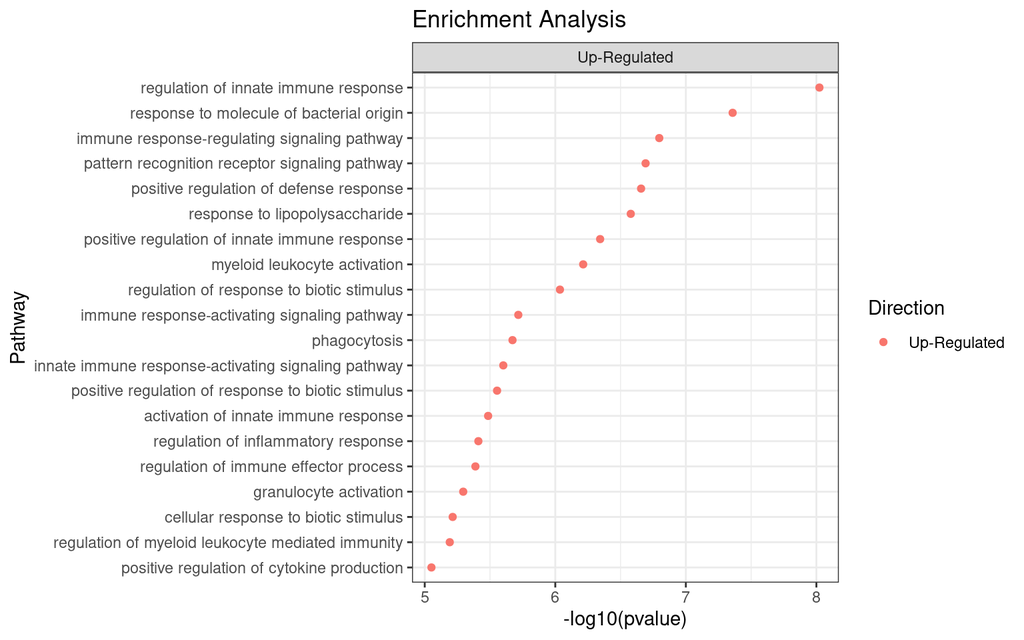

```r
# Plot the results
library(ggplot2)
gsea@result %>%
  mutate(Direction = ifelse(NES > 0, "Up-Regulated", "Down-Regulated"),
         Score = -log10(pvalue)) %>%
  top_n(20, Score) %>%
  ggplot(aes(x = Score, y = reorder(Description, Score), color = Direction)) + geom_point() + theme_bw() +
  labs(title = "Enrichment Analysis", x = "-log10(pvalue)", y = "Pathway") + facet_wrap(~Direction, scales = "free_y")
```

# 3 Visualizing Results

Bioinformatics is a field that is heavily reliant on visualization. In this section, we will cover some common visualizations used in bulk transcriptomics. There are so many different packages to visualize data in R. I have chosen a few that I think are the most useful.

## 3.1 Heatmaps

Heatmaps are a common visualization used in bulk transcriptomics. Heatmaps are used to visualize the expression of genes across samples. In this section, we will cover how to create heatmaps in R.

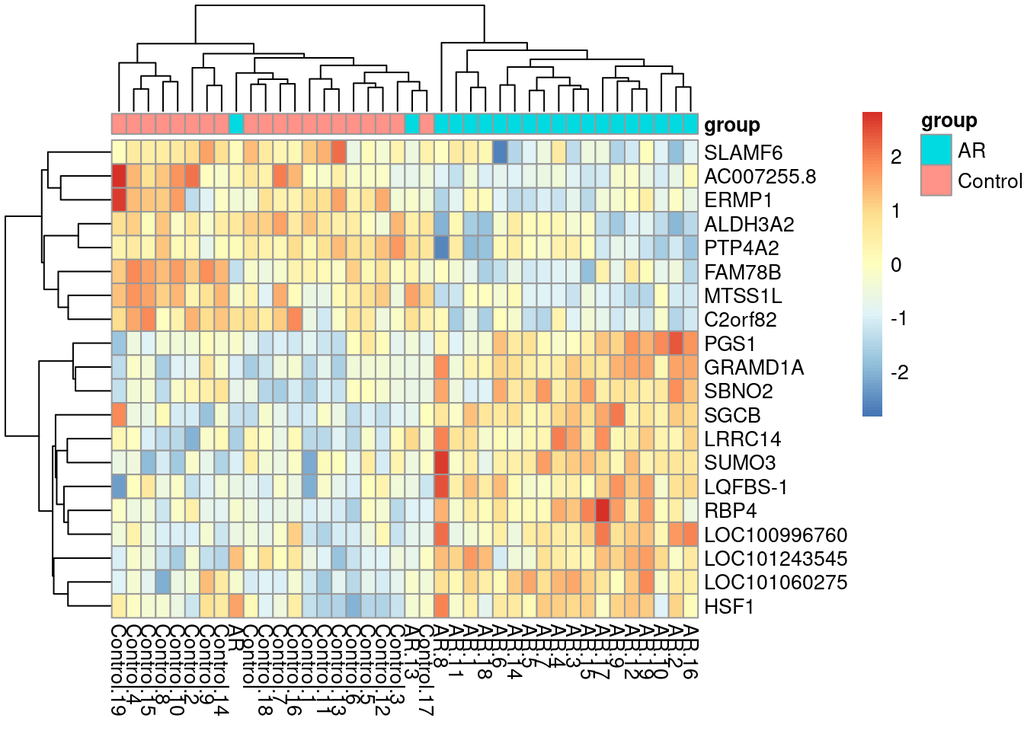

```r
library(pheatmap)
# Create a heatmap
top20_genes <- topTable %>%
  arrange(desc(abs(t))) %>%
  rownames() %>%
  head(20)

# Extract the counts for the top 20 genes
sig_counts = gse[top20_genes, ]

# Create the heatmap
# We can use the pheatmap function to create a heatmap.
# First we'll create an annotation matrix that contains the group information for each sample.
annotation = data.frame(group = patient_class, row.names = colnames(gse))
pheatmap(sig_counts,
         annotation = annotation,
         scale = "row", # This scales the rows of the heatmap. Be careful with this as it can make the heatmap look misleading.
         show_rownames = TRUE,
         show_colnames = TRUE)
```

## 3.2 Volcano Plots

Volcano plots are a common visualization used in bulk transcriptomics. Volcano plots are used to visualize the significance of genes across samples. In this section, we will cover how to create volcano plots in R.

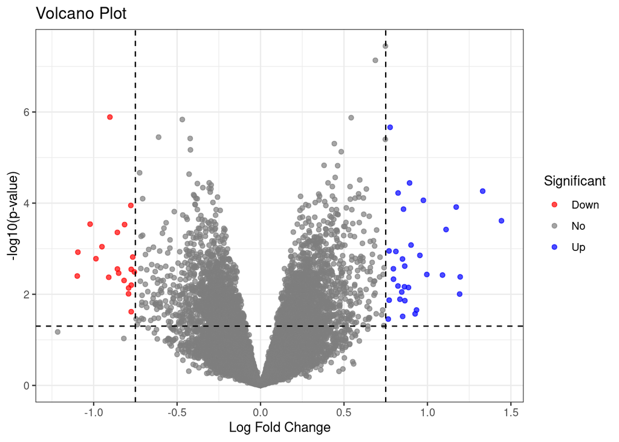

```r
library(ggplot2)
# Create a volcano plot
topTable %>%
  mutate(Significant = ifelse(P.Value < 0.05 & abs(logFC) > 0.75,
                              ifelse(logFC > 0, "Up", "Down"),
                              "No")) %>%
  ggplot(aes(x = logFC, y = -log10(P.Value), color = Significant)) + geom_point(alpha = 0.7) + theme_bw() +
  labs(title = "Volcano Plot", x = "Log Fold Change", y = "-log10(p-value)") + scale_color_manual(values = c("Up" = "blue", "Down" = "red", "No" = "grey50")) +
  geom_vline(xintercept = c(-0.75, 0.75), linetype = "dashed") +
  geom_hline(yintercept = -log10(0.05), linetype = "dashed")
```

## 3.3 MA Plots

M (Log Ratio) A (Average Expression) plots are a common visualization used in bulk transcriptomics. MA plots are used to visualize the relationship between the mean expression of genes and the difference in expression of genes. In this section, we will cover how to create MA plots in R.

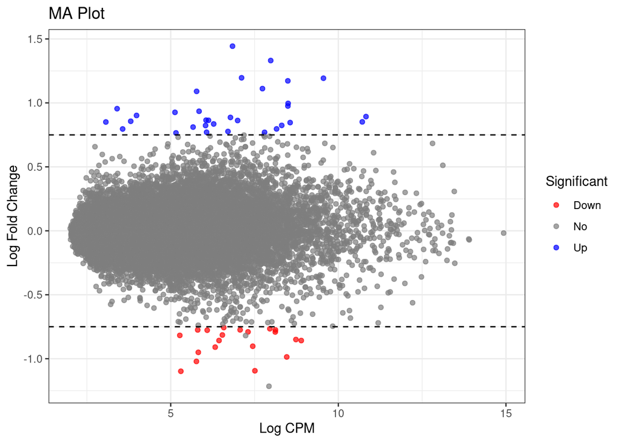

```r
# Create a MA plot
topTable %>%
  mutate(Significant = ifelse(P.Value < 0.05 & abs(logFC) > 0.75,
                              ifelse(logFC > 0, "Up", "Down"),
                              "No")) %>%
  ggplot(aes(x = AveExpr, y = logFC, color = Significant)) + geom_point(alpha = 0.7) + theme_bw() +
  labs(title = "MA Plot", x = "Log CPM", y = "Log Fold Change") + scale_color_manual(values = c("Up" = "blue", "Down" = "red", "No" = "grey50")) +
  geom_hline(yintercept = c(-0.75, 0.75), linetype = "dashed")
```